# Assignment 5

```python
# As we can see the dimensions plot seems to be straight from 9 or 10 onwards.
# So we are good to build the model based on 10 PCA components
pca = PCA(n_components=10)
pca.fit(X)

X = pca.transform(X)
```

Now let us start building Model . As mentioned in requirement , we will work on building model with Support Vector Machine and Naive Bayes And we will do a Cross Validation for a better result down the line

```python
# Splitting the Dataset into train and test set
from sklearn.naive_bayes import GaussianNB
from sklearn.svm import SVC

X_train,X_test,y_train,y_test = train_test_split(X,veh_df_y,test_size=0.30, random_state=42)
```

```python
#Using SVM and Grid Search to find the best Hyper Parameters

from sklearn.model_selection import GridSearchCV

model = SVC()

params = {'C' : [0.01, 0.05, 0.5,1], 'kernel' : ['linear','rbf']}


model1 = GridSearchCV(model, param_grid =params, verbose=5)
model1.fit(X_train,y_train)

print('Best Hyper Parameter: \n', model1.best_params_)
```

```
Fitting 3 folds for each of 8 candidates, totalling 24 fits
[CV] C=0.01, kernel=linear ...........................................
[CV] .. C=0.01, kernel=linear, score=0.8282828282828283, total=   0.1s
[CV] C=0.01, kernel=linear ...........................................
[CV] .. C=0.01, kernel=linear, score=0.8585858585858586, total=   0.0s
[CV] C=0.01, kernel=linear ...........................................
[CV] .. C=0.01, kernel=linear, score=0.8520408163265306, total=   0.0s
[CV] C=0.01, kernel=rbf ..............................................
```

```
[Parallel(n_jobs=1)]: Using backend SequentialBackend with 1 concurrent workers.
[Parallel(n_jobs=1)]: Done   1 out of   1 | elapsed:    0.1s remaining:    0.0s
[Parallel(n_jobs=1)]: Done   2 out of   2 | elapsed:    0.1s remaining:    0.0s
[Parallel(n_jobs=1)]: Done   3 out of   3 | elapsed:    0.2s remaining:    0.0s
```

```
[CV] ..... C=0.01, kernel=rbf, score=0.5252525252525253, total=   0.0s
[CV] C=0.01, kernel=rbf ..............................................
[CV] ..... C=0.01, kernel=rbf, score=0.5252525252525253, total=   0.0s
[CV] C=0.01, kernel=rbf ..............................................
[CV] ..... C=0.01, kernel=rbf, score=0.5255102040816326, total=   0.0s
[CV] C=0.05, kernel=linear ...........................................
```

```
[Parallel(n_jobs=1)]: Done   4 out of   4 | elapsed:    0.2s remaining:    0.0s
```

```
[CV] .. C=0.05, kernel=linear, score=0.8181818181818182, total=   0.4s
[CV] C=0.05, kernel=linear ...........................................
[CV] .. C=0.05, kernel=linear, score=0.8333333333333334, total=   0.1s
[CV] C=0.05, kernel=linear ...........................................
[CV] .. C=0.05, kernel=linear, score=0.8367346938775511, total=   0.2s
[CV] C=0.05, kernel=rbf ..............................................
[CV] ..... C=0.05, kernel=rbf, score=0.5252525252525253, total=   0.0s
[CV] C=0.05, kernel=rbf ..............................................
[CV] ..... C=0.05, kernel=rbf, score=0.5252525252525253, total=   0.0s
[CV] C=0.05, kernel=rbf ..............................................
[CV] ..... C=0.05, kernel=rbf, score=0.5255102040816326, total=   0.0s
[CV] C=0.5, kernel=linear ............................................
[CV] ... C=0.5, kernel=linear, score=0.8333333333333334, total=   3.4s
[CV] C=0.5, kernel=linear ............................................
[CV] ... C=0.5, kernel=linear, score=0.8484848484848485, total=   2.6s
[CV] C=0.5, kernel=linear ............................................
[CV] ... C=0.5, kernel=linear, score=0.8367346938775511, total=   1.4s
[CV] C=0.5, kernel=rbf ...............................................
[CV] ...... C=0.5, kernel=rbf, score=0.5252525252525253, total=   0.0s
[CV] C=0.5, kernel=rbf ...............................................
[CV] ...... C=0.5, kernel=rbf, score=0.5252525252525253, total=   0.0s
[CV] C=0.5, kernel=rbf ...............................................
[CV] ...... C=0.5, kernel=rbf, score=0.5255102040816326, total=   0.0s
[CV] C=1, kernel=linear ..............................................
[CV] ..... C=1, kernel=linear, score=0.8333333333333334, total=   4.5s
[CV] C=1, kernel=linear ..............................................
[CV] ..... C=1, kernel=linear, score=0.8484848484848485, total=   3.1s
[CV] C=1, kernel=linear ..............................................
[CV] ...... C=1, kernel=linear, score=0.826530612244898, total=   3.3s
[CV] C=1, kernel=rbf .................................................
[CV] ........ C=1, kernel=rbf, score=0.5252525252525253, total=   0.0s
[CV] C=1, kernel=rbf .................................................
[CV] ........ C=1, kernel=rbf, score=0.5252525252525253, total=   0.0s
[CV] C=1, kernel=rbf .................................................
[CV] ........ C=1, kernel=rbf, score=0.5255102040816326, total=   0.0s
Best Hyper Parameter:
 {'C': 0.01, 'kernel': 'linear'}
```

```
[Parallel(n_jobs=1)]: Done  24 out of  24 | elapsed:   19.8s finished
```

```python
model1.score(X_test, y_test)
```

```
0.8110236220472441
```

```python
model1.score(X_train,y_train)
```

```
0.8648648648648649
```

```python
#As we can see the model has better performed for the Train set as it is used to the data.
# So let us do a Cross Validation to find the accuracy

from sklearn.model_selection import cross_val_score, cross_val_predict

model1 = SVC(C=0.01, kernel='linear')
scores = cross_val_score(model1, X,veh_df_y,cv=10)

model1.fit(X_train,y_train)

print(scores)
```

```
[0.82352941 0.85882353 0.85882353 0.83529412 0.83529412 0.82352941
 0.87058824 0.82352941 0.85714286 0.85365854]
```

```python
print("Accuracy: %0.2f (+/- %0.2f)" % (scores.mean(), scores.std() * 2))
```

```
Accuracy: 0.84 (+/- 0.03)
```

```python
from sklearn.model_selection import ShuffleSplit
cv = ShuffleSplit(n_splits=8, test_size=0.3, random_state=0)
n_scores = cross_val_score(model1, X, veh_df_y, cv=cv)

print (n_scores)
```

```
[0.79527559 0.87007874 0.83858268 0.84251969 0.86614173 0.83858268
 0.86614173 0.83858268]
```

```python
print("Accuracy: %0.2f (+/- %0.2f)" % (scores.mean(), scores.std() * 2))
```

```
Accuracy: 0.84 (+/- 0.03)
```

```python
y_pred = model1.predict(X_test)
```

```python
# Print Classification Report
from sklearn.metrics import confusion_matrix, classification_report, accuracy_score

print(classification_report(y_test,y_pred))
print ('Accuracy Score :',accuracy_score(y_test, y_pred))
```

```
              precision    recall  f1-score   support

         bus       0.74      0.77      0.75        78
         car       0.82      0.78      0.80       118
         van       0.89      0.93      0.91        58

   micro avg       0.81      0.81      0.81       254
   macro avg       0.82      0.83      0.82       254
weighted avg       0.81      0.81      0.81       254

Accuracy Score : 0.8110236220472441
```

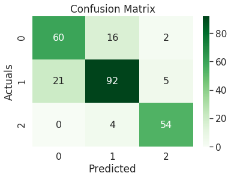

```python
from sklearn import metrics

cm=metrics.confusion_matrix(y_test, y_pred)
sns.set(font_scale=1.4) #for label size
plt.plot()
sns.heatmap(cm, annot=True,annot_kws={"size": 16} ,fmt='g',cmap='Greens')# font size..
ax= plt.subplot()
ax.set_xlabel('Predicted');ax.set_ylabel('Actuals');

ax.set_title('Confusion Matrix')
```

The Accuracy is not that good which we get from the Confusion matrix.

But Again the Recall is not that high and it is probably due to Class imbalance which we saw above.

Hence we can go for upsampling to increease the Recall and have a better accuracy.

```python
## Naive Bayes

model2 = GaussianNB()
scores = cross_val_score(model2,X,veh_df_y,cv=10)
print(scores)
```

```
[0.70588235 0.8        0.72941176 0.74117647 0.82352941 0.75294118
 0.78823529 0.72941176 0.78571429 0.7804878 ]
```

```python
print("Accuracy: %0.2f (+/- %0.2f)" % (scores.mean(), scores.std() * 2))
```

```
Accuracy: 0.76 (+/- 0.07)
```

```python
model2.fit(X_train,y_train)
y_pred = model2.predict(X_test)
```

```python
print(classification_report(y_test,y_pred))
print ('Accuracy Score :',accuracy_score(y_test, y_pred))
```

```
              precision    recall  f1-score   support

         bus       0.71      0.38      0.50        78
         car       0.78      0.81      0.79       118
         van       0.58      0.90      0.70        58

   micro avg       0.70      0.70      0.70       254
   macro avg       0.69      0.70      0.66       254
weighted avg       0.71      0.70      0.68       254

Accuracy Score : 0.6968503937007874
```

We can clearly see that the SVM performs better than Naive Bayes for this classification problem.

Hence we can go for SVM Model.

Again for better performance , we can do Hyper tuning and apply Ensemble techniques to get a better result.